# 抓取京东历史优惠活动公告信息_整理版_20171106

## 1.数据抓取

```python
# 爬虫及数据处理
import requests
import json
import lxml
import pandas as pd

# 分词及词云制作
import jieba
import wordcloud

# 作图
import matplotlib.pyplot as plt

# 作图风格设置
# http://www.cnblogs.com/lixiang-/p/5668164.html
plt.style.use('ggplot')

%matplotlib inline
```

### 错误处理

pip 安装wordcloud包的时候会报错——Unable to find vcvarsall.bat

https://www.megaleecher.net/Fix_error_misssing_vcvarsall

解决方案[参考地址](https://www.douban.com/note/484046487/)：

1. 下载编辑好的 .whl包 https://www.lfd.uci.edu/~gohlke/pythonlibs/
2. 先pip install wheel
3. pip install 包名字.whl 即可安装某模块包

```python
# 这里定义一个函数，将网址转化成html格式
# 区分get,post模式

import requests

def url2html(url,type = 'get',encoding='utf-8'):
    # 默认设置模式为get，编码格式为 utf-8
    try:
        if type == 'get':
            r = requests.get(url,timeout=120)
        elif type == 'post':
            r = requests.post(url,timeout=120)
    except requests.exceptions.ConnectTimeout:
        print('Wrong URL! Please Check')
    else:
        if r.status_code == 200:
            r.encoding = encoding
            content = r.text
        return content
```

# 要抓取的网址的格式如下： # https://www.jd.com/queryNews.html?type=2&title=&page=3' # 其中参数解释如下 # type = 2 就是【活动促销】栏目下的，信息，type=1是【京东公告】下的信息 # page = 3 这个就是页面序号

```python
# 首先定义一个数据框dataframe来存储数据
# 后面再将其转化为csv格式(csv格式的行容量大于xlsx格式)
df_res = pd.DataFrame()

# 页面序号作为循环变量
# 一共650个页面，这里使用range函数
# range函数有“左闭右开”的特征，及range(1,N)得到的序列长度为N-1
for page_id in range(1,651):
    # 每次抓取的网页地址
    url = 'https://www.jd.com/queryNews.html?type=2&title=&page=' + str(page_id)

    # 将网址转化为html
    html = url2html(url)

    # 将txt格式的html转化为json格式，即python中的dict格式
    html_json = json.loads(html)

    # 将json格式(或者dict格式)的数据转化为dataframe
    df_tmp = pd.DataFrame(html_json['record'])

    # 和保存数据的dataframe合并
    df_res = pd.concat([df_res,df_tmp])

# 后面我发现【京东公告】栏目下也有优惠信息，共171页
for page_id in range(172):
    # 每次抓取的网页地址
    url = 'https://www.jd.com/queryNews.html?type=1&title=&page=' + str(page_id)

    # 将网址转化为html
    html = url2html(url)

    # 将txt格式的html转化为json格式，即python中的dict格式
    html_json = json.loads(html)

    # 将json格式(或者dict格式)的数据转化为dataframe
    df_tmp = pd.DataFrame(html_json['record'])

    # 和保存数据的dataframe合并
    df_res = pd.concat([df_res,df_tmp])
```

```python
# 看看数据大小
df_res.shape
```

```
(24524, 8)
```

## 2.数据清洗

```python
# 看看数据内容
df_res.head()
```

|  | commentvisible | content | created | id | share | time | title | url |
| --- | --- | --- | --- | --- | --- | --- | --- | --- |
| 0 | None | None | 2017-07-17 15:02: | 34855 | None | 2017-07-17 15:02:40 | <font class="skcolor_ljg"></font>拼了，亿元好货5折抢！ | https://sale.jd.com/act/MwsDVQXEKlm.html |
| 1 | None | None | 2017-10-20 18:17: | 35760 | None | 2017-10-20 18:17:30 | <font class="skcolor_ljg"></font>想吃鸡吃的立体点？ | news.html?id=35760 |
| 2 | None | None | 2017-10-20 10:26: | 35755 | None | 2017-10-20 10:26:44 | <font class="skcolor_ljg"></font>预约平板得iPhoneX使... | news.html?id=35755 |
| 3 | None | None | 2017-10-19 14:24: | 35753 | None | 2017-10-19 14:24:51 | <font class="skcolor_ljg"></font>三星电视巅峰狂欢趴 | news.html?id=35753 |
| 4 | None | None | 2017-10-18 10:37: | 35740 | None | 2017-10-18 10:37:13 | <font class="skcolor_ljg"></font>长虹狂欢盛典，下单享千元优惠 | news.html?id=35740 |

```python
# 这里先备份一下数据，万一后面把原数据玩坏了，还可以恢复过来
df_res_bak = df_res

# 发现两个问题 commentviisble,content, share 这3列怎么都是None啊
df_res.describe()
```

|  | commentvisible | content | created | id | share | time | title | url |
| --- | --- | --- | --- | --- | --- | --- | --- | --- |
| count | 0.0 | 0.0 | 24524 | 24524 | 0.0 | 24524 | 24524 | 24524 |
| unique | 0.0 | 0.0 | 21278 | 24494 | 0.0 | 24457 | 20513 | 23130 |
| top | NaN | NaN | 2013-10-09 09:24: | 23792 | NaN | 2013-10-09 09:24:31 | <font class="skcolor_ljg"></font>月黑风高！挑战价格底限！ | //sale.jd.com/act/S2udRrNCGVnptb.html |
| freq | NaN | NaN | 8 | 2 | NaN | 8 | 238 | 26 |

```python
# 这3列都是空的啊，那就去掉吧
df_res = df_res.drop(['commentvisible','content','share'],axis = 1)
```

```python
# 然后 我想把日期格式改为 yyyy-mm-dd，以及title列中被<font>括住的内容都删除掉

# 日期转格式
import datetime

# 先转化成字符串，然后截取前10位
df_res['created'] = df_res['created'].apply(lambda x : str(x)[0:10])

# 再转化为日期格式
df_res['created'] = df_res['created'].apply(lambda x: datetime.datetime.strptime(x,'%Y-%m-%d'))

# 同样操作，修改列【time】的格式
df_res['time'] = df_res['time'].apply(lambda x : str(x)[0:10])
df_res['time'] = df_res['time'].apply(lambda x: datetime.datetime.strptime(x,'%Y-%m-%d'))

# 最后看一下效果如何
df_res.head()
```

|  | created | id | time | title | url |
| --- | --- | --- | --- | --- | --- |
| 0 | 2017-07-17 | 34855 | 2017-07-17 | <font class="skcolor_ljg"></font>拼了，亿元好货5折抢！ | https://sale.jd.com/act/MwsDVQXEKlm.html |
| 1 | 2017-10-20 | 35760 | 2017-10-20 | <font class="skcolor_ljg"></font>想吃鸡吃的立体点？ | news.html?id=35760 |
| 2 | 2017-10-20 | 35755 | 2017-10-20 | <font class="skcolor_ljg"></font>预约平板得iPhoneX使... | news.html?id=35755 |
| 3 | 2017-10-19 | 35753 | 2017-10-19 | <font class="skcolor_ljg"></font>三星电视巅峰狂欢趴 | news.html?id=35753 |
| 4 | 2017-10-18 | 35740 | 2017-10-18 | <font class="skcolor_ljg"></font>长虹狂欢盛典，下单享千元优惠 | news.html?id=35740 |

```python
# 现在处理【title】列那些被<font>括住的多余字符串
# 这里采用字符串分割法，通过“>”这个字符串，然后选择得到的列表的最后一个值即可

# 可以定义lambda函数来批量处理
# 使用分隔符 >
df_res['title'] = df_res['title'].apply(lambda x: x.split('>')[-1])
```

```python
# 看下最终效果如何,应该是很清爽了
df_res.head()
```

|  | created | id | time | title | url |
| --- | --- | --- | --- | --- | --- |
| 0 | 2017-07-17 | 34855 | 2017-07-17 | 拼了，亿元好货5折抢！ | https://sale.jd.com/act/MwsDVQXEKlm.html |
| 1 | 2017-10-20 | 35760 | 2017-10-20 | 想吃鸡吃的立体点？ | news.html?id=35760 |
| 2 | 2017-10-20 | 35755 | 2017-10-20 | 预约平板得iPhoneX使用权！ | news.html?id=35755 |
| 3 | 2017-10-19 | 35753 | 2017-10-19 | 三星电视巅峰狂欢趴 | news.html?id=35753 |
| 4 | 2017-10-18 | 35740 | 2017-10-18 | 长虹狂欢盛典，下单享千元优惠 | news.html?id=35740 |

```python
# 数据去重
# time列应该是活动日期，title是活动名称，这两列不应该有重复
df_res = df_res.drop_duplicates(['time','title'])

# 数据保存
# 一般使用csv格式，该格式下可以保存的数据行数远多于xlsx格式

df_res.to_csv('E:/Ahonglab/JD_Act_Info_20171106.csv',index = False)
```

## 载入离线数据

df_res = pd.read_csv('/Users/apple/desktop/pywork/Ahonglab/JD_Act_Info_20171104.csv',encoding = 'latin')

```python
# 会遇到报错
# 'utf-8' codec can't decode byte 0xc1 in position 2: invalid start byte
# 解决方法是该编码更通用的格式

df_res = pd.read_csv('E:/Ahonglab/JD_Act_Info_20171104.csv',encoding = 'latin')
# encoding = 'ISO-8859-1' 也是可以的

df_res.head()
```

|  | created | id | time | title | url |
| --- | --- | --- | --- | --- | --- |
| 0 | 2017-07-17 | 34855 | 2017-07-17 | Æ´ÁË£¬ÒÚÔªºûõ5ÕÛÇÀ£¡ | https://sale.jd.com/act/MwsDVQXEKlm.html |
| 1 | 2017-10-20 | 35760 | 2017-10-20 | Ïë³Ô¼¦³ÔµÄÁ¢Ìåµã£¿ | news.html?id=35760 |
| 2 | 2017-10-20 | 35755 | 2017-10-20 | Ô¤Ô¼Æ½°åµÃiPhoneXÊ¹ÓÃÈ¨£¡ | news.html?id=35755 |
| 3 | 2017-10-19 | 35753 | 2017-10-19 | ÈýÐÇµçÊÓáÛ·å¿ñ»¶Å¿ | news.html?id=35753 |
| 4 | 2017-10-18 | 35740 | 2017-10-18 | ³¤ºç¿ñ»¶Ê¢µä£¬Ïµ¥ÏíÇ§ÔªÓÅ»Ý | news.html?id=35740 |

```python
x = df_res.ix[1,3]
# 先用原编码方式转译为unicode，再通过gbk或者gb2312翻译成中文
x.encode('latin').decode('gbk')
```

```
'想吃鸡吃的立体点？ '
```

```python
df_res['title'] = df_res['title'].apply(lambda x : x.encode('latin').decode('gbk'))
df_res = df_res.drop_duplicates(['time','title'])
df_res.head()
```

|  | created | id | time | title | url |
| --- | --- | --- | --- | --- | --- |
| 0 | 2017-07-17 | 34855 | 2017-07-17 | 拼了，亿元好货5折抢！ | https://sale.jd.com/act/MwsDVQXEKlm.html |
| 1 | 2017-10-20 | 35760 | 2017-10-20 | 想吃鸡吃的立体点？ | news.html?id=35760 |
| 2 | 2017-10-20 | 35755 | 2017-10-20 | 预约平板得iPhoneX使用权！ | news.html?id=35755 |
| 3 | 2017-10-19 | 35753 | 2017-10-19 | 三星电视巅峰狂欢趴 | news.html?id=35753 |
| 4 | 2017-10-18 | 35740 | 2017-10-18 | 长虹狂欢盛典，下单享千元优惠 | news.html?id=35740 |

## 3.数据分析

这里我主要关注3个问题

1. 每月优惠活动数量趋势如何，月度或季度趋势么？
2. 优惠活动的常用关键字是啥？“减”“满”“拼”“惠”？
3. 不同品类的活动在频次上是否有差异，价格高的促销少？品类促销应该有季节波动，比如夏天卖空调、风扇等

```python
# 首先，请注意，在抓取的时候有一部分【公告】内容也跑进数据来了

# 我想到的一个方法是用关键字筛选

# 关键字列表，如果标题中出现其中一个关键字就被排除掉
keywords_notice = ['公告','影响','']
# 公告，延迟，影响，配送
# 服务，会员，修改，调整
# 上线，启用，正式，简介，产品
# 合作，战略

# 这里的关键词也是可以分类的，上线类的活动就意味着京东有新的功能或业务开展
# 这里也可以有一些分析点
```

```python
# 新增列变量来表示活动年、季、月
import math
df_res['act_year'] = df_res['created'].apply(str).apply(lambda x: x[2:4])
df_res['act_month'] = df_res['created'].apply(str).apply(lambda x: x[2:7])
df_res['act_season'] = df_res['created'].apply(str).apply(lambda x: x[2:4] + '-Q' + str(math.ceil(int(x[5:7])/3)))

df_res['season'] = df_res['created'].apply(str).apply(lambda x: 'Q' + str(math.ceil(int(x[5:7])/3)))
df_res['month'] = df_res['created'].apply(str).apply(lambda x: 'M'+x[5:7])
```

```python
df_res.head()
```

|  | created | id | time | title | url | act_year | act_month | act_season | season | month |
| --- | --- | --- | --- | --- | --- | --- | --- | --- | --- | --- |
| 0 | 2017-07-17 | 34855 | 2017-07-17 | 拼了，亿元好货5折抢！ | https://sale.jd.com/act/MwsDVQXEKlm.html | 17 | 17-07 | 17-Q3 | Q3 | M07 |
| 1 | 2017-10-20 | 35760 | 2017-10-20 | 想吃鸡吃的立体点？ | news.html?id=35760 | 17 | 17-10 | 17-Q4 | Q4 | M10 |
| 2 | 2017-10-20 | 35755 | 2017-10-20 | 预约平板得iPhoneX使用权！ | news.html?id=35755 | 17 | 17-10 | 17-Q4 | Q4 | M10 |
| 3 | 2017-10-19 | 35753 | 2017-10-19 | 三星电视巅峰狂欢趴 | news.html?id=35753 | 17 | 17-10 | 17-Q4 | Q4 | M10 |
| 4 | 2017-10-18 | 35740 | 2017-10-18 | 长虹狂欢盛典，下单享千元优惠 | news.html?id=35740 | 17 | 17-10 | 17-Q4 | Q4 | M10 |

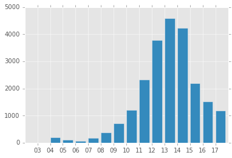

```python
# 年度活动情况
act_stat = df_res.groupby('act_year')['id'].count()

# 对groupby产生的MultiIndex转成DataFrame
# http://blog.csdn.net/qq_28219759/article/details/49083693
act_stat = act_stat.reset_index()
plt.bar(range(1,len(act_stat.act_year)+1),act_stat.id,tick_label = act_stat.act_year)
plt.show()
```

可以看到活动数量顶峰是在13年，这年京东正式启用短域名JD，且在14年初上市 估计和上市拉动用户人数和销量有关；

14年后逐渐下降，则可能是商业布局逐步成熟，用户补贴力度在逐步下降

```python
# 后面的分析则主要看10年以后的活动情况
act_info = df_res.loc[df_res['act_year'] >= '10']
# act_info = df_res.where(df_res['act_year'] >= '10')

# 活动是否有季节波动呢
act_stat = act_info.groupby(['act_year','season'])['id'].count()
# 用pivot_table 也可以达到同样效果
# act_stat = pd.pivot_table(act_info,values = 'id',index=['act_year','season'],aggfunc='count')

# 对groupby产生的MultiIndex转成DataFrame
# http://blog.csdn.net/qq_28219759/article/details/49083693
act_stat = act_stat.reset_index()

# 查看效果
act_stat.head()
```

|  | act_year | season | id |
| --- | --- | --- | --- |
| 0 | 10 | Q1 | 177 |
| 1 | 10 | Q2 | 284 |
| 2 | 10 | Q3 | 348 |
| 3 | 10 | Q4 | 386 |
| 4 | 11 | Q1 | 386 |

```python
# 分组bar
# https://chrisalbon.com/python/matplotlib_grouped_bar_plot.html
import matplotlib
# 提取颜色库
# https://stackoverflow.com/questions/22408237/named-colors-in-matplotlib
# http://www.cnblogs.com/darkknightzh/p/6117528.html
colorset = [hex for name, hex in matplotlib.colors.cnames.items() if 'FF'  in hex and '00'  in hex]

import random
# 用于颜色随机抽样

def groupbar(df,idx,cols,title = 'GroupBarRes',xlabel = 'x label',ylabel='y label'):
    # Setting the positions and width for the bars
    col_cnt = len(cols)
    colors = random.sample(colorset,col_cnt)

    pos = list(range(len(df[idx])))
    width = 0.2

    # Plotting the bars
    fig, ax = plt.subplots(figsize=(10,5))

    # 循环作图
    for i,col in enumerate(cols):
        plt.bar([p + width*i for p in pos],df[col],width,alpha=0.5,color = colors[i])

    # 图表标题
    ax.set_title(title)
    # Y轴标题
    ax.set_ylabel(ylabel)
    # X轴标题
    ax.set_xlabel(xlabel)
    # X轴标签位置
    ax.set_xticks([p + 1.5 * width for p in pos])
    # X轴标签
    ax.set_xticklabels(df[idx])
    # 坐标轴范围
    plt.xlim(min(pos)-width, max(pos)+width*4)
    plt.ylim([0, max([max(df[i]) for i in cols])*1.1])
    # 添加图例
    plt.legend(cols, loc='upper left')
    #plt.grid()
    plt.show()
```

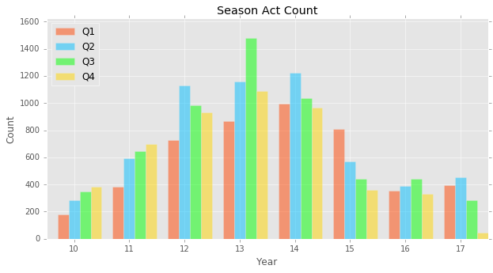

```python
# reshape 一下dataframe，展开season列，以便画图
act_stat_shaped = act_stat.pivot(index='act_year',columns='season',values='id')

# act_stat_shaped.head()
act_stat_shaped = act_stat_shaped.reset_index()

# 作图
groupbar(df=act_stat_shaped,idx='act_year',cols=['Q1','Q2','Q3','Q4']\
        ,title = 'Season Act Count'\
        ,xlabel = u'Year'\
        ,ylabel = u'Count')
```

```python
act_stat_shaped.head()
```

| season | act_year | Q1 | Q2 | Q3 | Q4 |
| --- | --- | --- | --- | --- | --- |
| 0 | 10 | 177 | 284 | 348 | 386 |
| 1 | 11 | 386 | 591 | 648 | 697 |
| 2 | 12 | 727 | 1131 | 984 | 934 |
| 3 | 13 | 865 | 1160 | 1478 | 1089 |
| 4 | 14 | 997 | 1225 | 1038 | 967 |

```python
# 这里会报错
# AttributeError: 'float' object has no attribute 'decode'
# 所以加了个float 筛选这部分数据，发现都是nan
# 可以加一个isinstans(i,float) 来筛选数据
```

```python
# =================== 1. 分词 ===================
# 补充词典,有些词语不在jieba词典中，e.g.笔记本，游戏本等
jieba.load_userdict('E:/Ahonglab/dict_add.txt')

# 设置list用来存储分词结果
words_list = list()
for idx,val in enumerate(act_info['title']):
    # 非全模式分词
    list_temp = jieba.lcut(val,cut_all=False)
    # list合并
    words_list += list_temp
```

```
Building prefix dict from the default dictionary ...
Loading model from cache D:\Users\hongsheng.cheng\AppData\Local\Temp\jieba.cache
Loading model cost 1.291 seconds.
Prefix dict has been built succesfully.
```

```python
len(words_list)
```

```
164773
```

```python
# =================== 2.清洗 ===================
# 清洗分词结果
# 清除数字，中文标点，英文标点，空格，空值
# 一般优惠金额都是整数，11.11这类也是数字，不过有特殊含义，就不去掉了

# 英文符号
import string
mark_en = list(string.punctuation)

# 中文标点
mark_ch = [' ','，','。','、','？','！','“','”','；'\
           ,'：','（','）','《','》','【','】','·','|','……']

words_list_fil = [i for i in words_list if len(i)>0 \
            and not i.isdigit()
            and i not in mark_ch \
            and i not in mark_en \
           ]
len(words_list_fil)
```

```
110889
```

```python
# =================== 3. 计数===================
# 转数据格式
s = pd.Series(words_list_fil)
# 计数
word_freq = pd.DataFrame(s.value_counts()).reset_index()
# 重命名列
word_freq.columns = ['word','freq']

word_freq.sort_values('freq',ascending=False).to_csv('E:/Ahonglab/group_stat.csv')

word_freq.head()
```

|  | word | freq |
| --- | --- | --- |
| 0 | 减 | 1707 |
| 1 | 京东 | 1668 |
| 2 | 元 | 1630 |
| 3 | 满 | 1560 |
| 4 | 折 | 1322 |

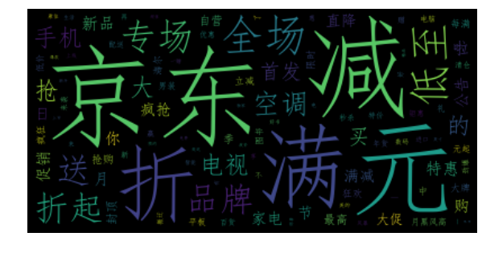

```
<wordcloud.wordcloud.WordCloud at 0xf338310>
```

```python
# =================== 4. 画词云图 ===================
word_freq = dict( zip(word_freq['word'],word_freq['freq']))

# http://blog.csdn.net/fyuanfena/article/details/52038984
# 中文显示问题
font = r'C:\Windows\Fonts\simfang.ttf'

wc = wordcloud.WordCloud(font_path = font,
                background_color="black", #背景颜色
                max_words=2000,# 词云显示的最大词数
                max_font_size=100, #字体最大值
                random_state=42,
                margin=10
                )
wc.generate_from_frequencies(word_freq)

plt.figure(figsize=(10,5))

# 以下代码显示图片
plt.imshow(wc)
plt.axis("off")
plt.show()

# 保存图片
wc.to_file('E:/Ahonglab/JD_act_cloud.png')
```

满减和折扣是活动的主要方式啊

抽奖，买赠的还是比较少

*哪些品类优惠活动更频繁呢?*

看了下wordcloud和统计结果

出现频率最高的是空调、手机、电视

手机、电视是目前的主要娱乐设备，空调则是让玩耍的时候跟舒服一点

这三件也基本属于家家必备的高单价物品

也许消费频率、单价是促销要考虑的两个重要因素

至于我关注的图书和食品，真是呵呵了，一年难得几回啊

```python
# 我要看下图书一般都什么时候做活动啊

# 筛选标题有【图书】的活动
act_info['book_mark'] = act_info['title'].apply(lambda x : 'Y' if '图书' in str(x) else 'N')
```

```python
del act_info['book_mark']
```

```python
act_info.head()
```

[output not shown]

```python
act_info_book = act_info.loc[act_info['book_mark'] == 'Y']
act_info_book.shape
```

```
(262, 11)
```

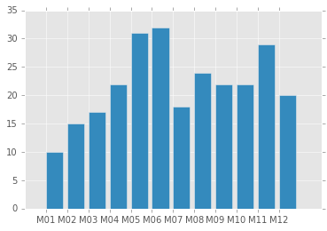

```python
book_stat = act_info_book.groupby('month')['id'].count()

book_stat = book_stat.reset_index()

plt.bar(range(1,len(book_stat.month)+1),book_stat.id,tick_label = book_stat.month)
plt.show()
```

```python
# 我去，活动每月都有？为啥我没看到

# 近三年呢
act_info_book = act_info_book.loc[act_info_book['act_year'] >= '15']
```

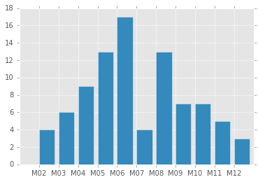

```python
book_stat = act_info_book.groupby('month')['id'].count()

book_stat = book_stat.reset_index()

plt.bar(range(1,len(book_stat.month)+1),book_stat.id,tick_label = book_stat.month)
plt.show()
```

呵呵，7月活动少是因为放暑假么，9月则是因为开学

6月这个高，应该不是大促，6月有高考啊

```python
book_stat = act_info_book.groupby(['month','act_year'])['id'].count()
book_stat = book_stat.reset_index()
book_stat_shaped = book_stat.pivot(index='month',columns='act_year',values='id')
book_stat_shaped = book_stat_shaped.reset_index()
```

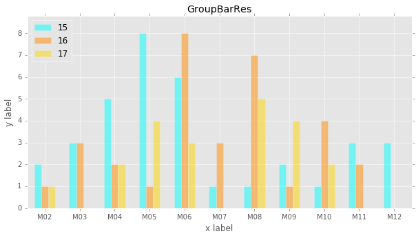

```python
groupbar(df = book_stat_shaped,idx = 'month',cols=['15','16','17'])
```